# INN Hotels Project

#### Visualizing Tree

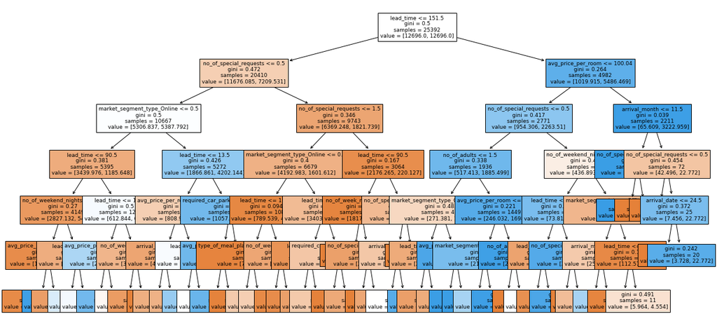

```python
# code taken from Session_Notebook_Machine_Failure_Prediction.ipynb

feature_names = list(X_train_t.columns)
importances = estimator.feature_importances_
indices = np.argsort(importances)

plt.figure(figsize=(20, 10))
out = tree.plot_tree(
    estimator,
    feature_names=feature_names,
    filled=True,
    fontsize=9,
    node_ids=False,
    class_names=None,
)
# below code will add arrows to the decision tree split if they are missing
for o in out:
    arrow = o.arrow_patch
    if arrow is not None:
        arrow.set_edgecolor("black")
        arrow.set_linewidth(1)
plt.show()
```

```python
# Text report showing the rules of a decision tree -
print(tree.export_text(estimator, feature_names=feature_names, show_weights=True))
```

```
|--- lead_time <= 151.50
|   |--- no_of_special_requests <= 0.50
|   |   |--- market_segment_type_Online <= 0.50
|   |   |   |--- lead_time <= 90.50
|   |   |   |   |--- no_of_weekend_nights <= 0.50
|   |   |   |   |   |--- avg_price_per_room <= 196.50
|   |   |   |   |   |   |--- weights: [1736.39, 132.08] class: 0
|   |   |   |   |   |--- avg_price_per_room >  196.50
|   |   |   |   |   |   |--- weights: [0.75, 25.81] class: 1
|   |   |   |   |--- no_of_weekend_nights >  0.50
|   |   |   |   |   |--- lead_time <= 68.50
|   |   |   |   |   |   |--- weights: [960.27, 223.16] class: 0
|   |   |   |   |   |--- lead_time >  68.50
|   |   |   |   |   |   |--- weights: [129.73, 160.92] class: 1
|   |   |   |--- lead_time >  90.50
|   |   |   |   |--- lead_time <= 117.50
|   |   |   |   |   |--- avg_price_per_room <= 93.58
|   |   |   |   |   |   |--- weights: [214.72, 227.72] class: 1
|   |   |   |   |   |--- avg_price_per_room >  93.58
|   |   |   |   |   |   |--- weights: [82.76, 285.41] class: 1
|   |   |   |   |--- lead_time >  117.50
|   |   |   |   |   |--- no_of_week_nights <= 1.50
|   |   |   |   |   |   |--- weights: [87.23, 81.98] class: 0
|   |   |   |   |   |--- no_of_week_nights >  1.50
|   |   |   |   |   |   |--- weights: [228.14, 48.58] class: 0
|   |   |--- market_segment_type_Online >  0.50
|   |   |   |--- lead_time <= 13.50
|   |   |   |   |--- avg_price_per_room <= 99.44
|   |   |   |   |   |--- arrival_month <= 1.50
|   |   |   |   |   |   |--- weights: [92.45, 0.00] class: 0
|   |   |   |   |   |--- arrival_month >  1.50
|   |   |   |   |   |   |--- weights: [363.83, 132.08] class: 0
|   |   |   |   |--- avg_price_per_room >  99.44
|   |   |   |   |   |--- lead_time <= 3.50
|   |   |   |   |   |   |--- weights: [219.94, 85.01] class: 0
|   |   |   |   |   |--- lead_time >  3.50
|   |   |   |   |   |   |--- weights: [132.71, 280.85] class: 1
|   |   |   |--- lead_time >  13.50
|   |   |   |   |--- required_car_parking_space <= 0.50
|   |   |   |   |   |--- avg_price_per_room <= 71.92
```

[output cut: 93 more lines]

```
|   |   |   |   |   |   |--- weights: [5.96, 4.55] class: 0
|   |--- avg_price_per_room >  100.04
|   |   |--- arrival_month <= 11.50
|   |   |   |--- no_of_special_requests <= 2.50
|   |   |   |   |--- weights: [0.00, 3200.19] class: 1
|   |   |   |--- no_of_special_requests >  2.50
|   |   |   |   |--- weights: [23.11, 0.00] class: 0
|   |   |--- arrival_month >  11.50
|   |   |   |--- no_of_special_requests <= 0.50
|   |   |   |   |--- weights: [35.04, 0.00] class: 0
|   |   |   |--- no_of_special_requests >  0.50
|   |   |   |   |--- arrival_date <= 24.50
|   |   |   |   |   |--- weights: [3.73, 0.00] class: 0
|   |   |   |   |--- arrival_date >  24.50
|   |   |   |   |   |--- weights: [3.73, 22.77] class: 1
```

#### Feature Importance

- Next, we will check feature importance.

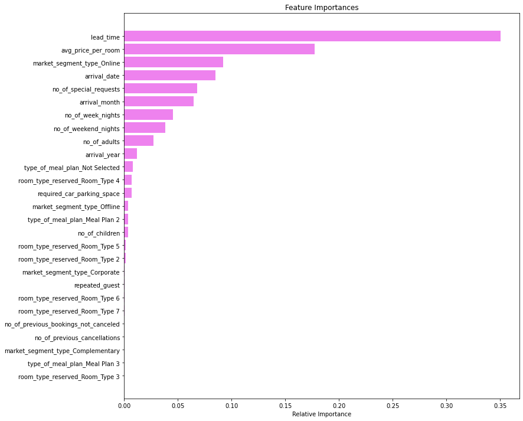

```python
# code taken from Additional_CaseStudy_Loan_Deliquent_DSBA.ipynb
feature_names = list(X_train_t.columns)
importances = tree_model.feature_importances_
indices = np.argsort(importances)

plt.figure(figsize=(12, 12))
plt.title("Feature Importances")
plt.barh(range(len(indices)), importances[indices], color="violet", align="center")
plt.yticks(range(len(indices)), [feature_names[i] for i in indices])
plt.xlabel("Relative Importance")
plt.show()
```

#### Observations:

- lead_time appears to be the most important feature in predicting booking cancellations.
- avg_price_per_room is also important, but only by about half when compared to lead time.

## Do we need to prune the tree?

- We should probably do some post pruning on the decision tree using cost complexity.

```python
# cost complexity pruning - taken from Session_Notebook_Machine_Failure_Prediction.ipynb
clf = DecisionTreeClassifier(random_state=1, class_weight="balanced")
path = clf.cost_complexity_pruning_path(X_train_t, y_train_t)
ccp_alphas, impurities = abs(path.ccp_alphas), path.impurities

pd.DataFrame(path)
```

|  | ccp_alphas | impurities |
| --- | --- | --- |
| 0 | 0.00000 | 0.00838 |
| 1 | -0.00000 | 0.00838 |
| 2 | 0.00000 | 0.00838 |
| 3 | 0.00000 | 0.00838 |
| 4 | 0.00000 | 0.00838 |
| ... | ... | ... |
| 1887 | 0.00890 | 0.32806 |
| 1888 | 0.00980 | 0.33786 |
| 1889 | 0.01272 | 0.35058 |
| 1890 | 0.03412 | 0.41882 |
| 1891 | 0.08118 | 0.50000 |

1892 rows × 2 columns

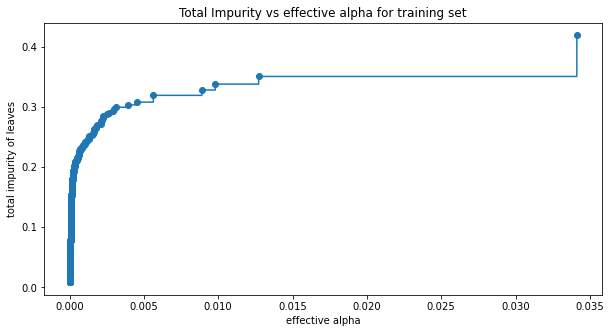

```python
# plotting impurity vs effective alpha from train set
fig, ax = plt.subplots(figsize=(10, 5))
ax.plot(ccp_alphas[:-1], impurities[:-1], marker="o", drawstyle="steps-post")
ax.set_xlabel("effective alpha")
ax.set_ylabel("total impurity of leaves")
ax.set_title("Total Impurity vs effective alpha for training set")
plt.show()
```

```python
# train using effective alphas - taken from Session_Notebook_Machine_Failure_Prediction.ipynb
clfs = []
for ccp_alpha in ccp_alphas:
    clf = DecisionTreeClassifier(
        random_state=1, ccp_alpha=ccp_alpha, class_weight="balanced"
    )
    clf.fit(X_train_t, y_train_t)
    clfs.append(clf)
print(
    "Number of nodes in the last tree is: {} with ccp_alpha: {}".format(
        clfs[-1].tree_.node_count, ccp_alphas[-1]
    )
)
```

```
Number of nodes in the last tree is: 1 with ccp_alpha: 0.08117914389136932
```

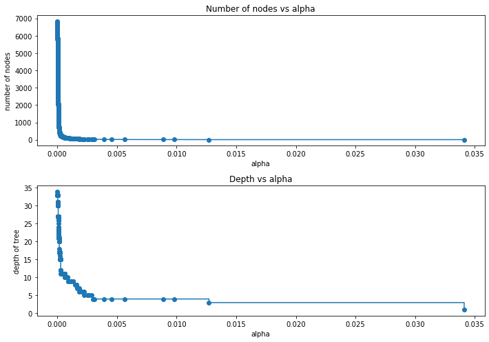

```python
# plotting nodes vs alphas & depth vs alphas - taken from Session_Notebook_Machine_Failure_Prediction.ipynb
clfs = clfs[:-1]
ccp_alphas = ccp_alphas[:-1]

node_counts = [clf.tree_.node_count for clf in clfs]
depth = [clf.tree_.max_depth for clf in clfs]
fig, ax = plt.subplots(2, 1, figsize=(10, 7))
ax[0].plot(ccp_alphas, node_counts, marker="o", drawstyle="steps-post")
ax[0].set_xlabel("alpha")
ax[0].set_ylabel("number of nodes")
ax[0].set_title("Number of nodes vs alpha")
ax[1].plot(ccp_alphas, depth, marker="o", drawstyle="steps-post")
ax[1].set_xlabel("alpha")
ax[1].set_ylabel("depth of tree")
ax[1].set_title("Depth vs alpha")
fig.tight_layout()
```

```python
# training F1 vs alpha - taken from Session_Notebook_Machine_Failure_Prediction.ipynb
f1_train = []
for clf in clfs:
    pred_train = clf.predict(X_train_t)
    values_train = f1_score(y_train_t, pred_train)
    f1_train.append(values_train)

f1_test = []
for clf in clfs:
    pred_test = clf.predict(X_test_t)
    values_test = f1_score(y_test_t, pred_test)
    f1_test.append(values_test)
```

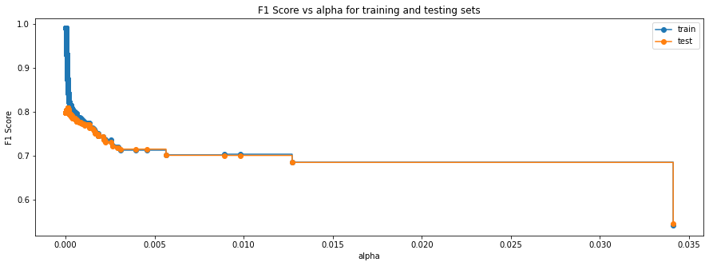

```python
# plotting F1 score vs alpha - taken from Session_Notebook_Machine_Failure_Prediction.ipynb
fig, ax = plt.subplots(figsize=(15, 5))
ax.set_xlabel("alpha")
ax.set_ylabel("F1 Score")
ax.set_title("F1 Score vs alpha for training and testing sets")
ax.plot(ccp_alphas, f1_train, marker="o", label="train", drawstyle="steps-post")
ax.plot(ccp_alphas, f1_test, marker="o", label="test", drawstyle="steps-post")
ax.legend()
plt.show()
```

```python
# creating the model where we get highest train and test F1 - taken from Session_Notebook_Machine_Failure_Prediction.ipynb
index_best_model = np.argmax(f1_test)
best_model = clfs[index_best_model]
print(best_model)
```

```
DecisionTreeClassifier(ccp_alpha=0.00012267633155167018,
                       class_weight='balanced', random_state=1)
```

- Next we will check the model performance for initial, tuning, and post pruning.

## Model Performance Comparison and Conclusions

#### Comparison on Best Model

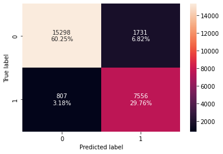

```python
# confusion matrix for best model
confusion_matrix_sklearn(best_model, X_train_t, y_train_t)
```

```python
# model performance
decision_tree_post_perf_train = model_performance_classification_sklearn(
    best_model, X_train_t, y_train_t
)
print('Train performance, post pruning:')
decision_tree_post_perf_train
```

```
Train performance, post pruning:
```

|  | Accuracy | Recall | Precision | F1 |
| --- | --- | --- | --- | --- |
| 0 | 0.90005 | 0.90350 | 0.81361 | 0.85620 |

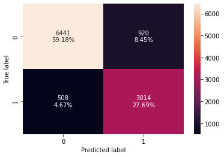

```python
# confusion matrix for best model, test
confusion_matrix_sklearn(best_model, X_test_t, y_test_t)
```

```python
# model performance
decision_tree_post_perf_test = model_performance_classification_sklearn(
    best_model, X_test_t, y_test_t
)
print('Test performance, post pruning:')
decision_tree_post_perf_test
```

```
Test performance, post pruning:
```

|  | Accuracy | Recall | Precision | F1 |
| --- | --- | --- | --- | --- |
| 0 | 0.86879 | 0.85576 | 0.76614 | 0.80848 |

#### Decision Tree Comparison

```python
# train
train_models = pd.concat(
    [
        decision_tree_perf_train.T,
        decision_tree_tune_perf_train.T,
        decision_tree_post_perf_train.T,
    ],
    axis=1,
)
train_models.columns = [
    "Initial",
    "Pre-Pruning",
    "Post-Pruning",
]
print("Training performance comparison:")
train_models
```

```
Training performance comparison:
```

|  | Initial | Pre-Pruning | Post-Pruning |
| --- | --- | --- | --- |
| Accuracy | 0.99421 | 0.83101 | 0.90005 |
| Recall | 0.98661 | 0.78620 | 0.90350 |
| Precision | 0.99578 | 0.72428 | 0.81361 |
| F1 | 0.99117 | 0.75397 | 0.85620 |

```python
# test
test_models = pd.concat(
    [
        decision_tree_perf_test.T,
        decision_tree_tune_perf_test.T,
        decision_tree_post_perf_test.T,
    ],
    axis=1,
)
test_models.columns = [
    "Initial",
    "Pre-Pruning",
    "Post-Pruning",
]
print("Test performance comparison:")
test_models
```

```
Test performance comparison:
```

|  | Initial | Pre-Pruning | Post-Pruning |
| --- | --- | --- | --- |
| Accuracy | 0.87118 | 0.83497 | 0.86879 |
| Recall | 0.81034 | 0.78336 | 0.85576 |
| Precision | 0.79543 | 0.72758 | 0.76614 |
| F1 | 0.80281 | 0.75444 | 0.80848 |

#### Observations:

- The tree with post-pruning has higher accuracy, recall, precision, and F1 score than the pre-prunned. This is true on both the train and test sets.
- Therefore, we will choose the decision tree with post-pruning as the final model.

## Actionable Insights and Recommendations

- Since the lead time was identified as the most important feature affecting canceled bookings, INN Hotels could implement a policy that specifies a certain amount of time in which a booking can be made. This would help cut down on reservations that are made very far in advanced and then ultimately end up being canceled.
  - Similarily, INN Hotels could implement a policy that specifies that refunds (or prorated refunds) can only be given up to a certain point in time. This would help recoup some of the costs on last minute cancellations where it is harder to fill a vacancy on short notice.
- Repeat guests are less likely to have a hotel cancellation, so INN Hotels could implement some type of customer loyalty program or similar rewards program that emphasizes an incentive for the customers to come back and stay at the hotel chain again in the future.
  - Additionally, there could be some type of referal program where loyalty members get additional rewards for recommending friends and family to stay at the hotel.
- Because price per room is higher, on average, in cases where there has been a booking cancellation, INN Hotels might want to do an industry study to determine whether or not their prices are competitive in relation to other hotels in the area. A good way to retain customers is to make sure that prices are competitive to other businesses near by.
- Duration of stay is another factor that INN Hotels may want to consider. The longer the stay, the more likely it is that the booking will be cancelled. Maybe INN Hotels can add an additional non-refundable fee to any stay that is over a certain length of time.
- Looking at the most popular room type (room type 1), it has the most bookings and least cancellations. INN Hotels might want to take some of the successes they have in marketing/promoting this type of room and use them to help get more successful bookings on some of the other room types.
- Lastly, INN Hotels could look at offering special seasonal pricing during the off season. Autumn and Winter have the least amount of bookings compared to Spring and Summer. Increasing the amount of time that these rooms are booked year-round will have a siginficant impact on INN Hotels' profits.